# Proyecto 2

Oliver Mazariegos, Rafael Leon y Alejandro Vasquez

18/8/2018

# Situaci?n Problem?tica

No se ha buscado la relacion entre habilidades cognitivas, crecimiento y salud de los huesos utilizando los datos del estudio longitudinal de la UVG y los estudios que se han realizado con datos parecidos no han sido bien investigados en paises de bajos y medianos ingresos.

Los datos utilizados para este analisis son el producto de un estudio longitudinal dise?ado por el Dr. Barry Bogin hace mas de 50 a?os en conjunto con el Colegio Americano de Guatemala. Ellos se propusieron a colectar datos longitudinalmente de estudiantes de todos los a?os y darle seguimiento a su crecimiento de forma anual hasta el momento en el que completaban sus estudios de bachillerato. El estudio se expandi? a 6 colegios m?s a lo largo de los a?os y se cuenta con datos de peso, talla, IQ, pruebas de lectura y masa osea para registros comenzando en el a?o 1953.

Esta base de datos pertenece a la fundaci?n Bill and Melinda Gates, los cuales donaron los fondos necesarios para digitalizarla.

# Problema Cientifico

Los niños del dataset escogido tienen una estatura menor a los niños de otros paises para los mismos grupos etarios. Se está buscando formas de extrapolar los datos de la base de datos a nivel nacional para poder utilizar macroindicadores para buscar una razón por la cual los niños de Guatemala son más pequeños.

## Objetivos

### General

- DiseÃ±ar un modelo predictivo para estatura y/o peso basado en los datos disponibles del estudio longitudinal del Dr. Bogin para poder tener datos representativos de la realidad nacional.

### EspecÃficos

- Realizar un analisis exploratorio de los datos para determinar la forma apropiada de diseÃ±ar el modelo predictivo sugerido.
- DiseÃ±ar un modelo predictivo para peso y/o talla
- Probar distintos modelos predictivos diferentes para compararlos entre sÃ y escoger el mejor.
- Realizar una limpieza general de los Datos a utilizar.

# Conjunto de datos

## Leyendo Datos

- Subjects: Informacion personal de cada sujeto de prueba.
- Card1: Informacion fisiol?gica de los sujetos.
- Card2: Informacion fisiol?gica complementaria.

```r
subjects = as.data.table(read_xlsx("./data/1-Subjects sex_ID_school_DOB.xlsx"))
card1 = as.data.table(read_xlsx("./data/4-Card1.xlsx"))
card2 = as.data.table(read_xlsx("./data/5-Card2.xlsx"))
```

### Variables desechadas

En las tres bases de datos existen registros de control de digitalizacion como.

- `entering date`: Fecha en la que los datos fueron digitalizados.
- `User` : Usuario que digitaliz? el dato.

Estas variables, por ser solo de control, junto a `Repetition` en `Card1` y `Card2`, que no esta presente en casi todo el conjunto de datos, seran desechadas.

### Subject

En Subjects podemos encontrar las siguientes variables personales de cada sujeto de estudio.

- `ID`: Identificador personal para cada persona involucrada en el set de datos.
- `DOB`: Fecha de nacimiento de la persona.
- `DOB decimal`: A?o de nacimiento de la persona en representacion decimal.
- `Sex`: Sexo de la persona.
- `IdSchool 1`: Identificador del colegio al que asisti? la persona.
- `IdSchool 2`: Valor booleano que representa si el sujeto ya no estudia en el colegio representado en `IdSchool 1`

### Card1

En Card1 podemos encontrar las siguientes caracteristicas fisiologicas de los sujetos de observacion.

- `yearCard1`: A?o en el que se recopilaron los datos.
- `gradeCard1`: Grado escolar al que pertenec?a la persona.
- `Height`: Altura de la persona en centimetros.
- `Weight`: Peso de la persona en kg.
- `Hand grip`: Fuerza de la mano calculado en kg.
- `Dental`: Dentici?n piezas del sujeto. N?mero de piezas permanentes eruptadas.

### Card2

En Card2 podemos encontrar las siguientes caracteristicas fisiologicas de los sujetos de observacion.

- `yearCard2`: A?o en el que se recopilaron los datos.
- `grade Card 2`: Grado escolar al que pertenec?a la persona.
- `UAC1`: Circunferencia Tricep 1
- `UAC2`: Circunferencia Tricep 2
- `TST1`: Pliegue Cut?neo Tricep 1
- `TST2`: Pliegue Cut?neo Tricep 2
- `SSF1`: Pliegue Cut?neo Subescapular 1
- `SSF2`: Pliegue Cut?neo Subescapular 2

## Union y Limpieza de Datos

### Subject-Card1-Card2

```r
mainData = subjects
c1 = card1
c2 = card2

colnames(mainData)[1] <- "Id"
colnames(c1)[2] <- "date"
colnames(c2)[2] <- "date"

cards <- merge(c1, c2, by = c("Id", "date"))
completeData <- merge(mainData, cards, by = "Id")
completeData$age <- round(completeData$date - completeData$`DOB decimal`, 0)
```

# Analisis Exploratorio

## Card1-Card2

### Exploraci?n de variables y eliminacion de outlier

#### Frecuencia de edades

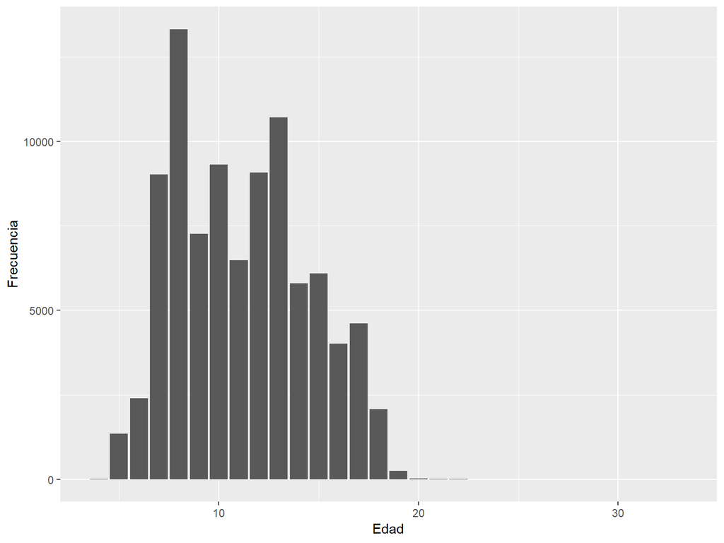

```r
ggplot(completeData, aes(x = age)) +
  geom_bar() +
  labs(x = "Edad", y = "Frecuencia")
```

#### Altura por Edad

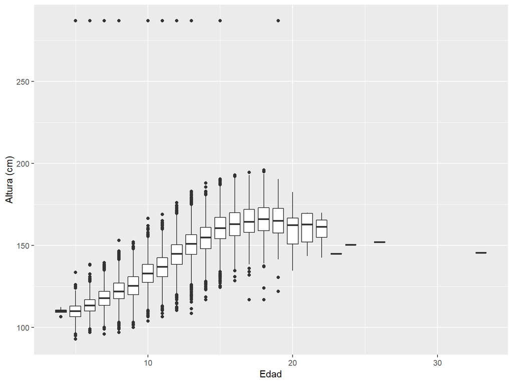

```r
ggplot(completeData, aes(group = age, x = age, y = Height)) +
  geom_boxplot() +
  labs(x = "Edad", y = "Altura (cm)")
```

Las alturas de m?s de 250 cm no tienen sentido. Adem?s, las edades mayores a 22 a?os tienen muy pocos datos. Se decidi? removerlos:

```r
completeData <- completeData %>%
  filter(Height < 250) %>%
  filter(age < 23)
```

##### Sin outliers

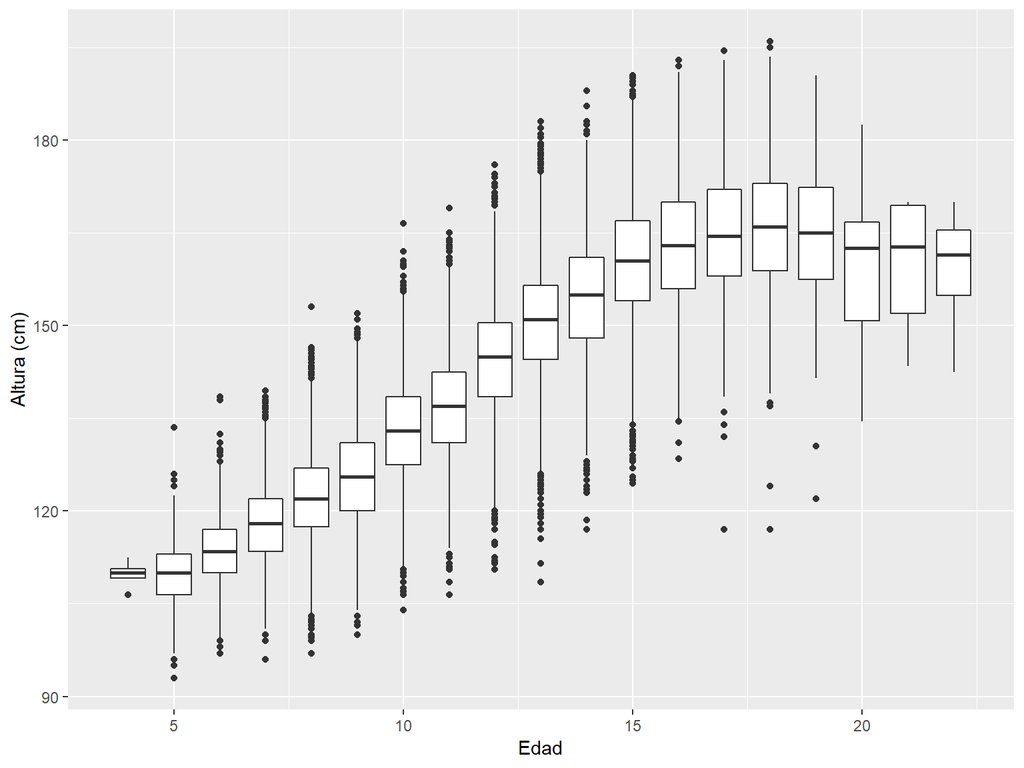

```r
ggplot(completeData, aes(group = age, x = age, y = Height)) +
  geom_boxplot() +
  labs(x = "Edad", y = "Altura (cm)")
```

#### Pesos por Edades

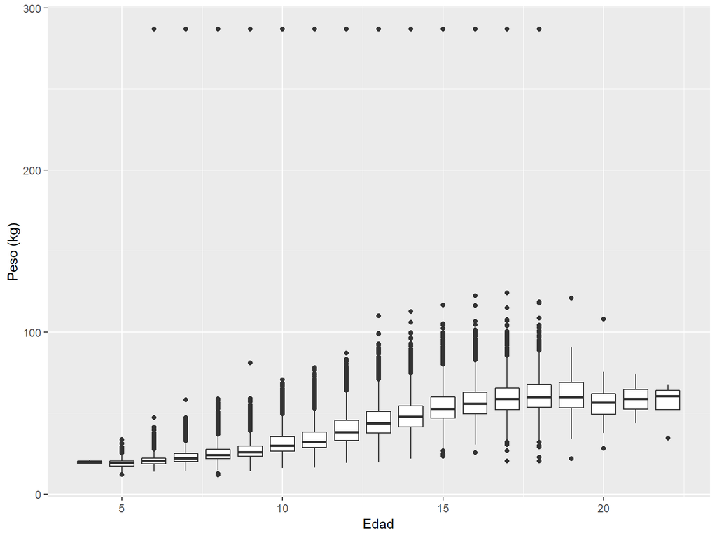

```r
ggplot(completeData, aes(group = age, x = age, y = Weight)) +
  geom_boxplot() +
  labs(x = "Edad", y = "Peso (kg)")
```

Pesos mayores a 200 kg no tienen sentidos. Se decidi? eliminarlos:

```r
completeData <- completeData %>%
  filter(Weight < 200)
```

##### Sin outliers

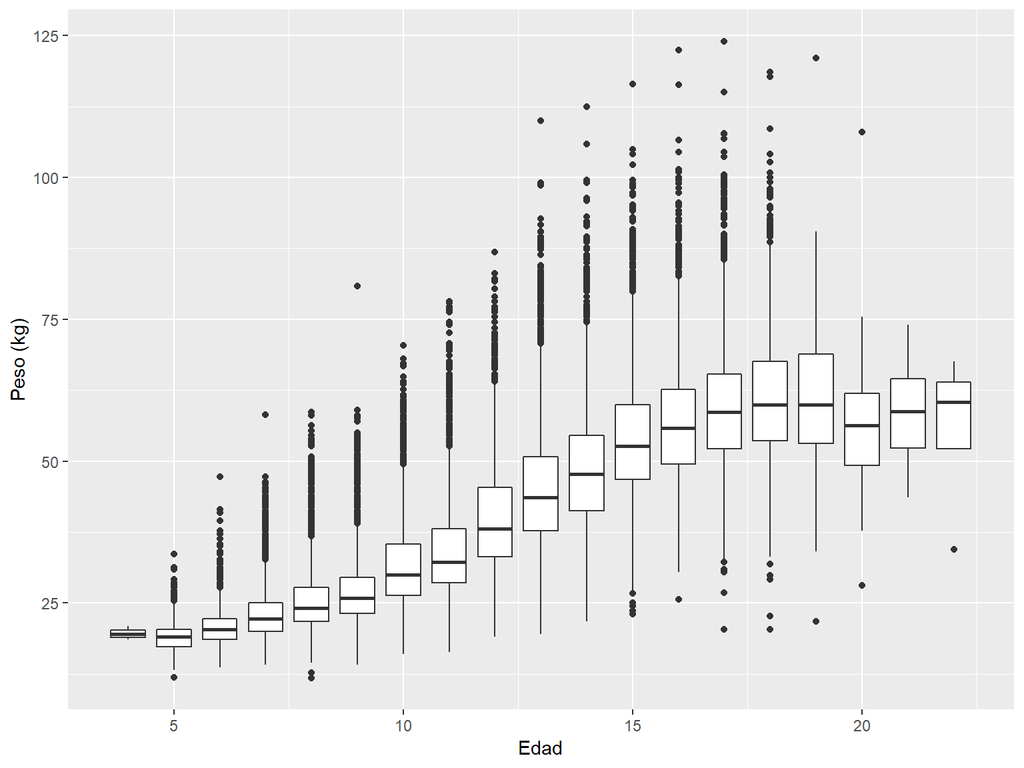

```r
ggplot(completeData, aes(group = age, x = age, y = Weight)) +
  geom_boxplot() +
  labs(x = "Edad", y = "Peso (kg)")
```

#### Regresion Lineal Peso-Altura

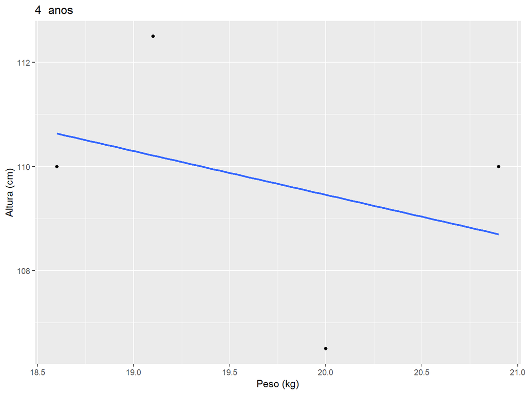

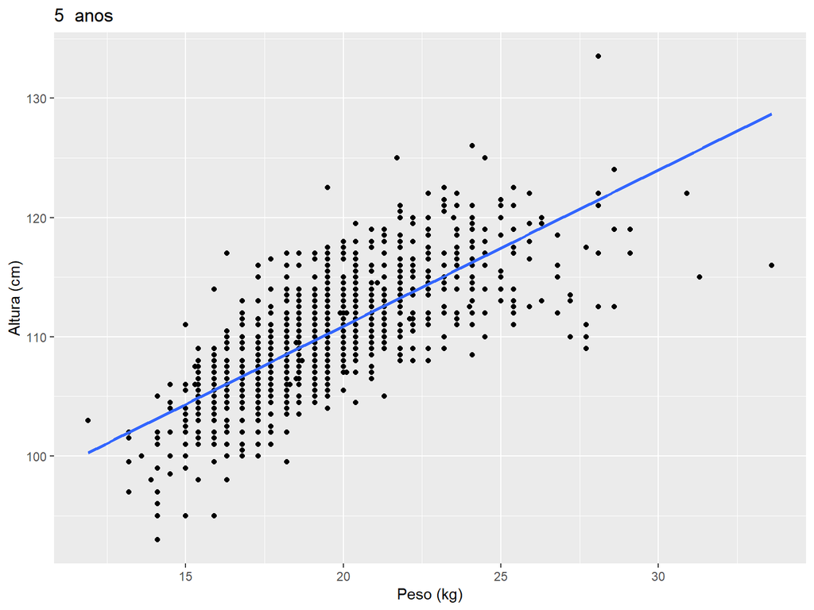

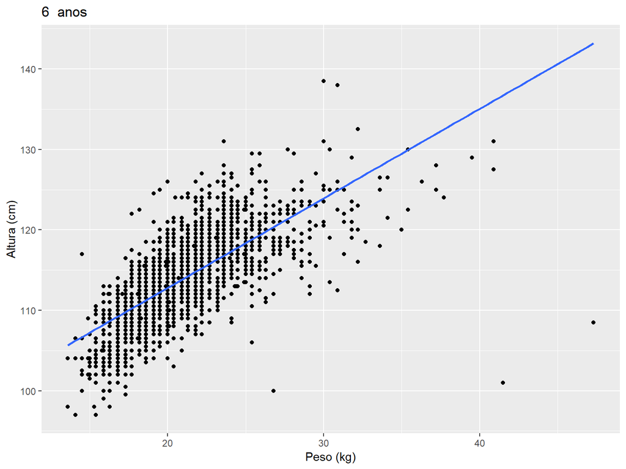

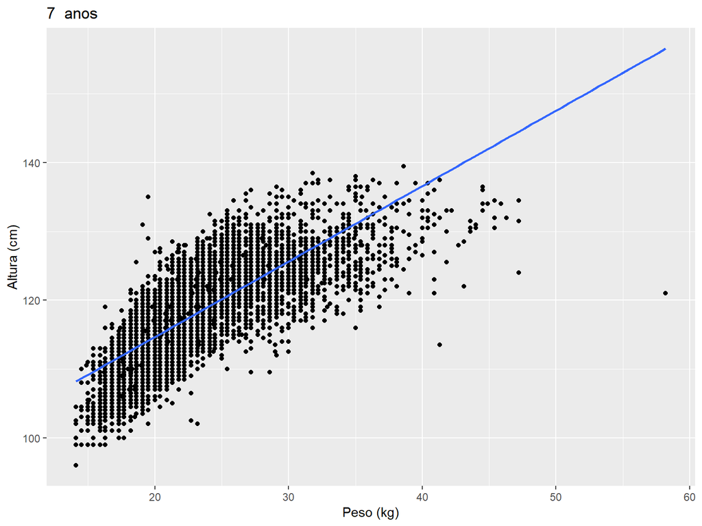

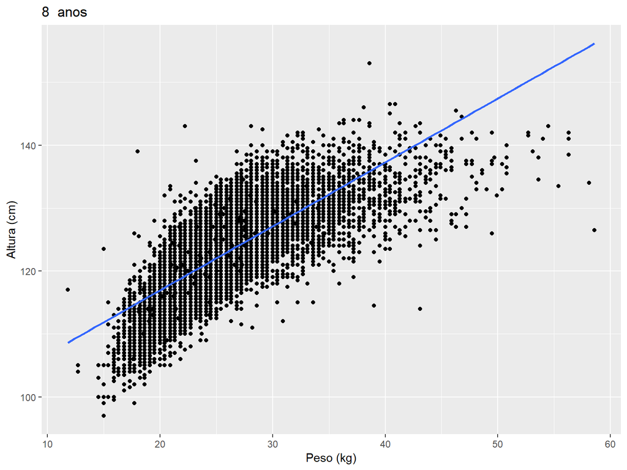

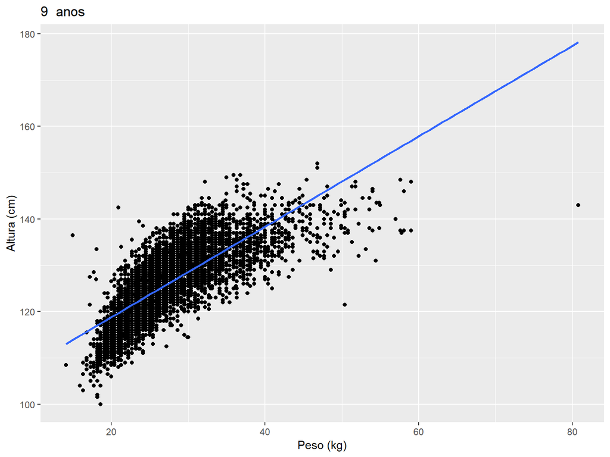

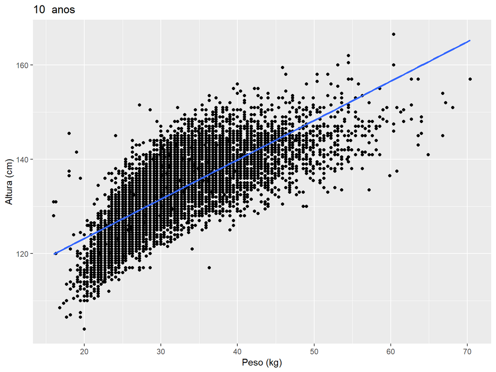

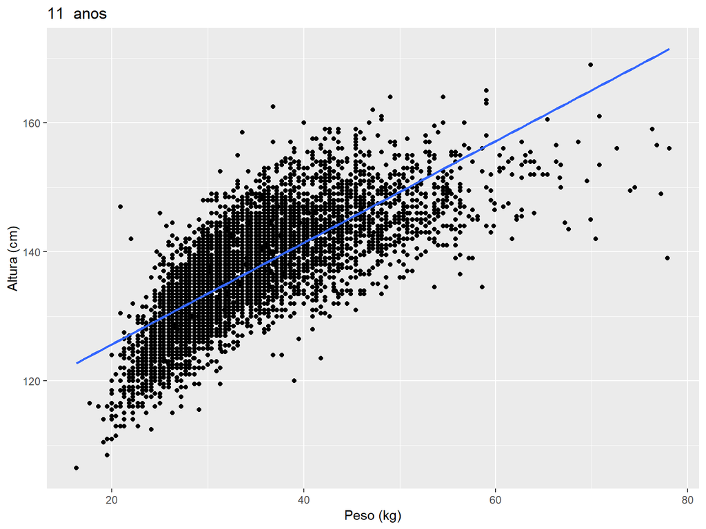

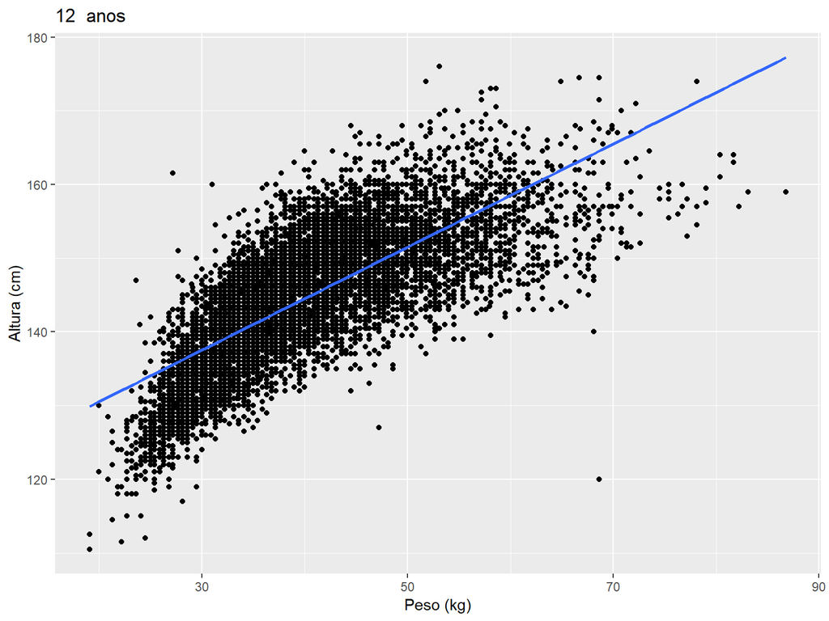

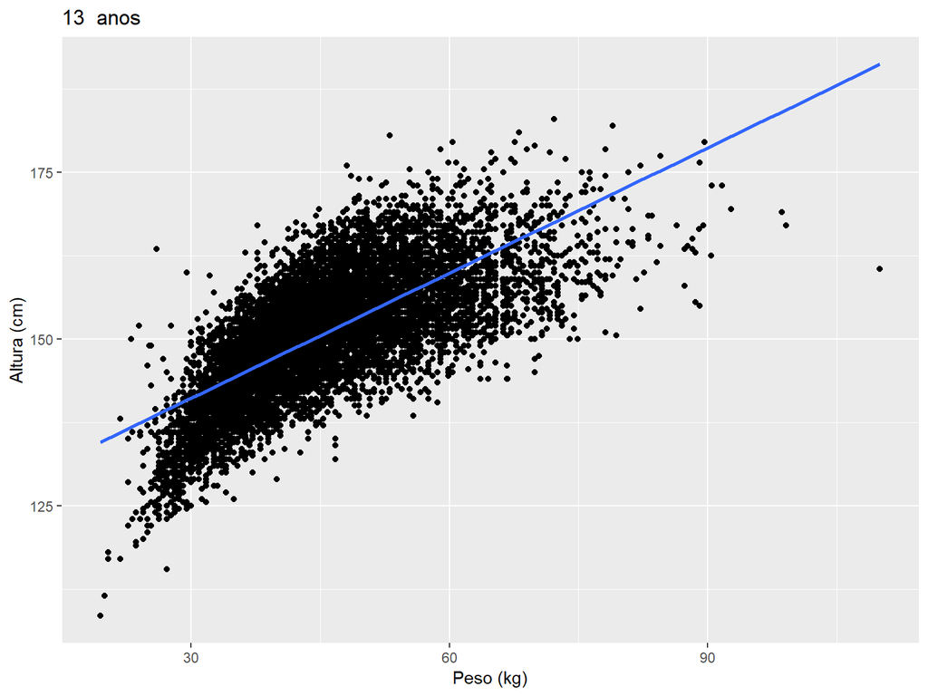

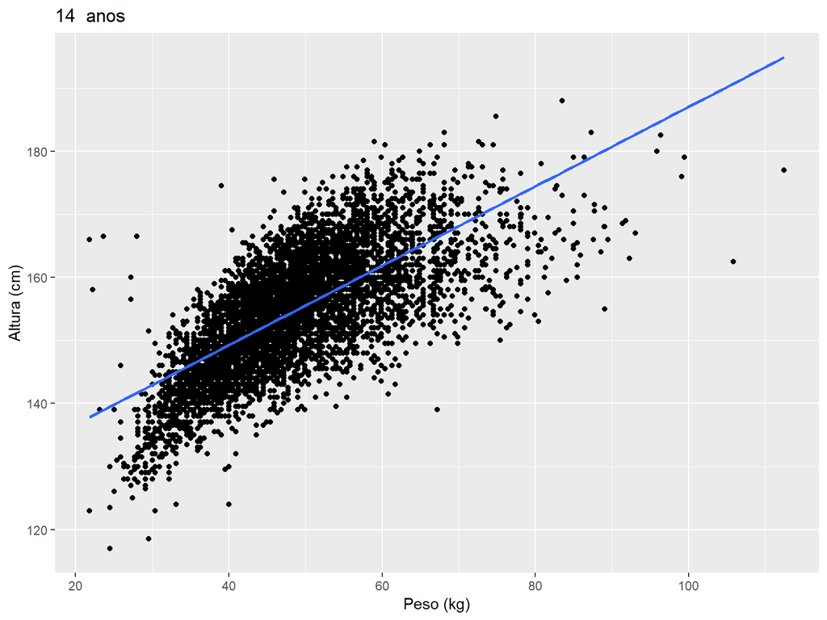

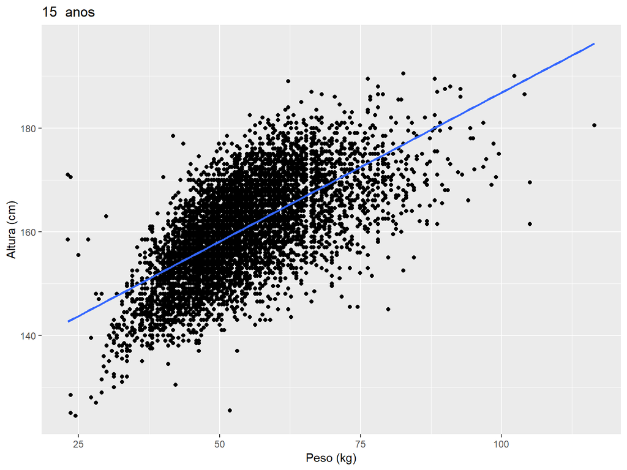

[7 more figures not shown]

```r
for(i in 4:22){
  temp <- completeData %>%
    filter(age == i)

  print(ggplot(temp, aes(x = Weight, y = Height)) + geom_point() +
           labs(x = "Peso (kg)", y = "Altura (cm)", title = paste(i, " anos")) +
    geom_smooth(method = lm, se = F))
}
```

Solo existen 4 datos para mediciones con cuatro y veintidos años de edad. Se eliminarán:

```r
completeData <- completeData %>%
  filter(age > 4) %>%
  filter(age < 22)
```

#### Altura-Dientes

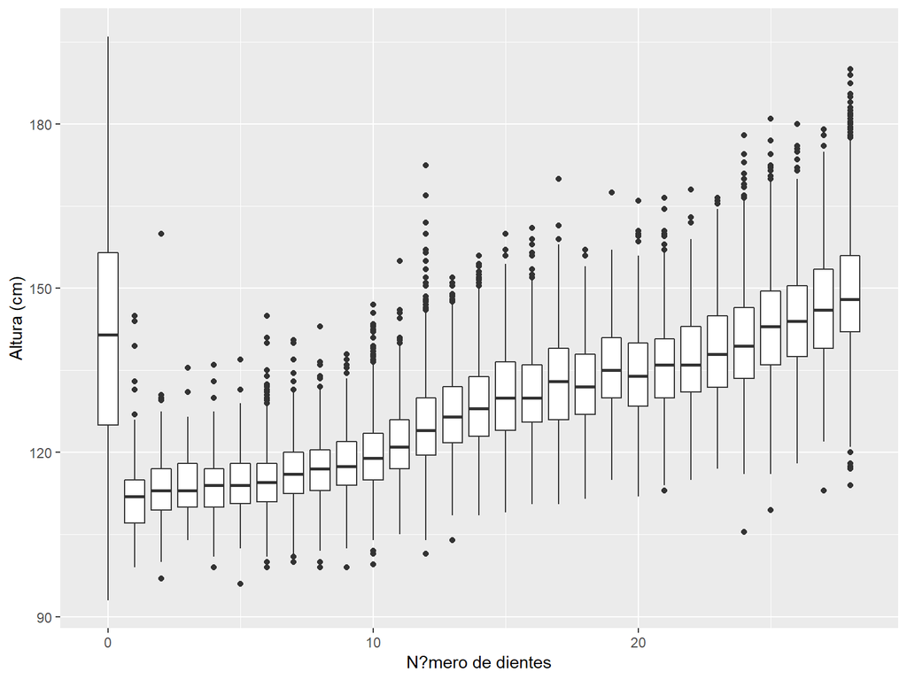

```r
ggplot(completeData, aes(group = Dental, x = Dental, y = Height)) +
  geom_boxplot() +
  labs(x = "N?mero de dientes", y = "Altura (cm)")
```

No tiene sentido que hayan ni?os tan altos sin dientes permanentes “erupcionados”. Seg?n la Asociaci?n Dental de Am?rica, se espera que a partir de los 6-7 a?os por lo menos se hayan desarrollado los incisivos centrales. Probablemente esos “0”s signifiquen que no fue registrado el dato. Para comprobar cu?ntos registros de ni?os mayores a?os no tienen dientes permanentes “erupcionados”:

```r
paste(round((nrow(filter(completeData, age > 7 & Dental == 0))
             / nrow(completeData) * 100),2), "%")
```

```
## [1] "62.46 %"
```

M?s del 60% de los datos no tienen ese registro, por lo que no se utilizar? esta columna.

```r
completeData <- completeData %>%
  mutate(Dental = NULL)
```

#### IdSchool | Repetition | RepetitionCard1

IdSchool2, que indica si se cambiaron de colegio parece tener muchos NAs. Chequear:

```r
paste(round(nrow(filter(completeData, is.na(`IdSchool 2`))) /
              nrow(completeData) * 100, 2), "%")
```

```
## [1] "99.86 %"
```

Casi el 100% de los registros no poseen esta informaci?n. Se eliminar? esta columna. Adem?s, se eliminar?n las columnas *Repetition* y *RepetitionCard1* ya que estas proveen poca informaci?n acerca de la altura. Es m?s, los alumnos repitentes podr?an distorsionar las predicciones.

```r
completeData <- completeData %>%
  mutate(`IdSchool 2` = NULL) %>%
  mutate(Repetition = NULL) %>%
  mutate(RepetitionCard1 = NULL)
```

#### Fuerza de Agarre (Hand grip)

Visualizar los datos de pruebas de fuerza de agarre:

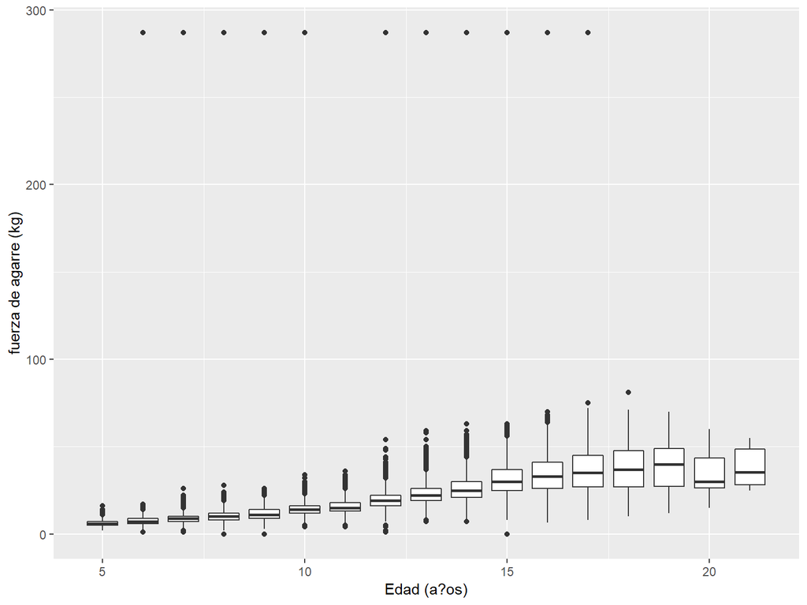

```r
ggplot(completeData, aes(y = `Hand grip`, x = age, group = age)) +
  geom_boxplot() +
  labs(y = "fuerza de agarre (kg)", x = "Edad (a?os)")
```

No existen registros de pruebas de fuerza de agarre en los que se superen los 100 kg de fuerza de agarre, por lo que se eliminar?n los outliers y se vuelve a graficar:

```r
completeData <- completeData %>%
  filter(`Hand grip` < 100)
```

##### Sin outliers

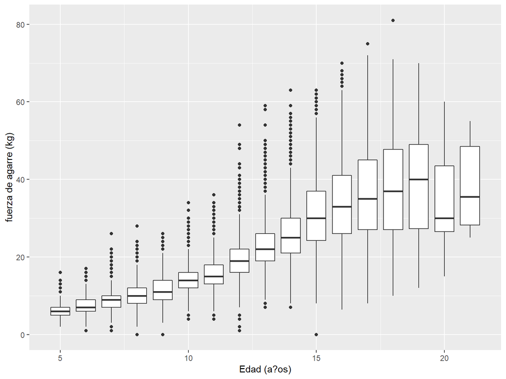

```r
ggplot(completeData, aes(y = `Hand grip`, x = age, group = age)) +
  geom_boxplot() +
  labs(y = "fuerza de agarre (kg)", x = "Edad (a?os)")
```

#### Fuerza de Agarre-Edad

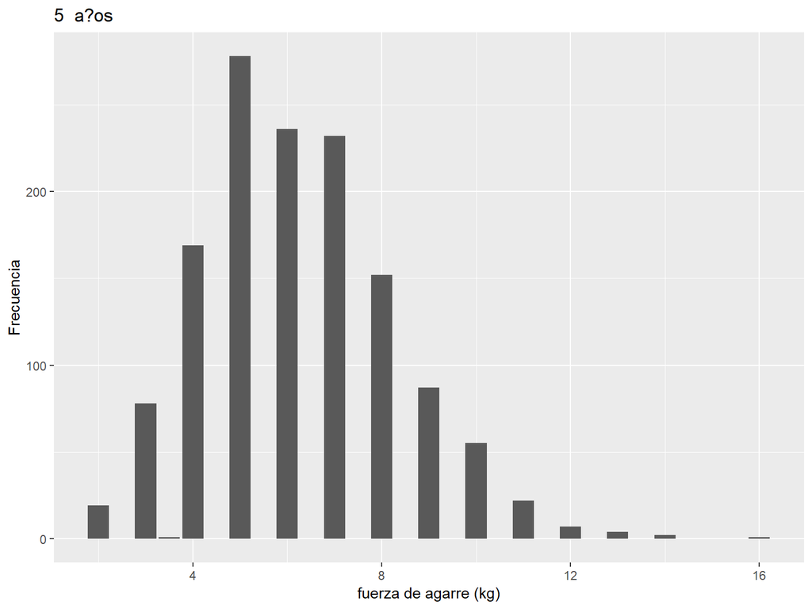

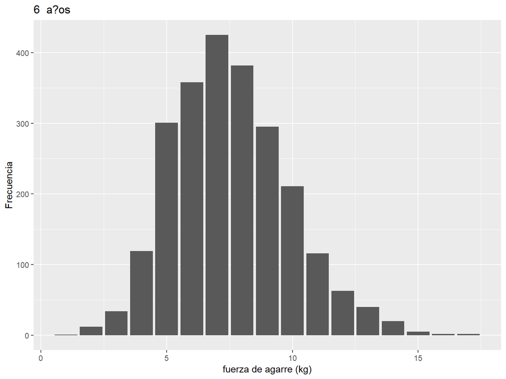

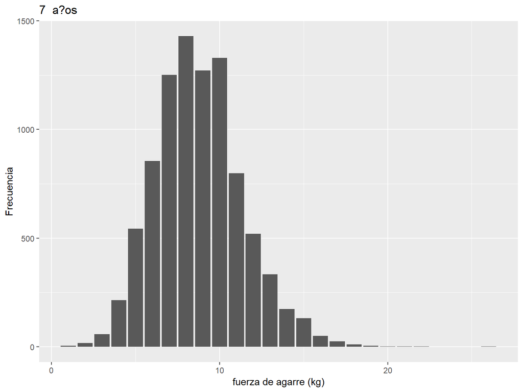

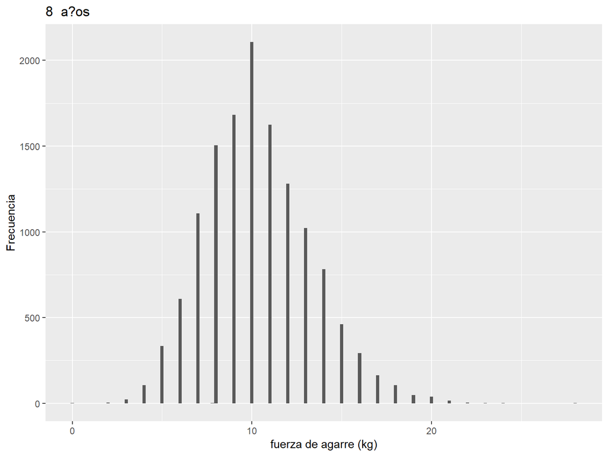

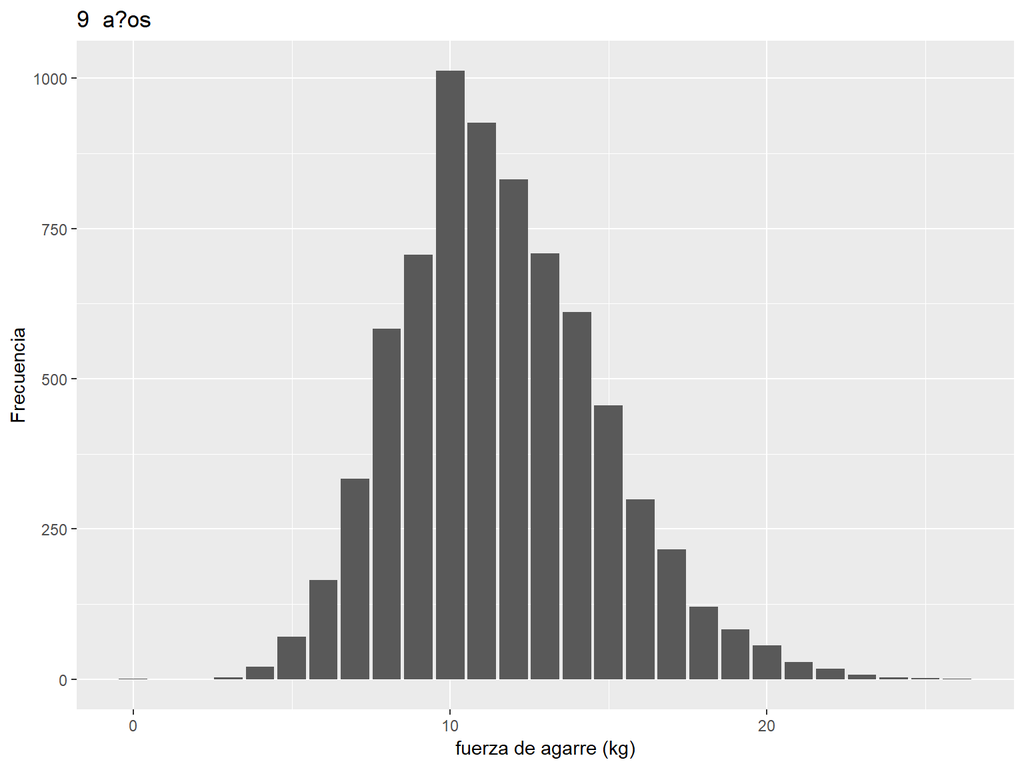

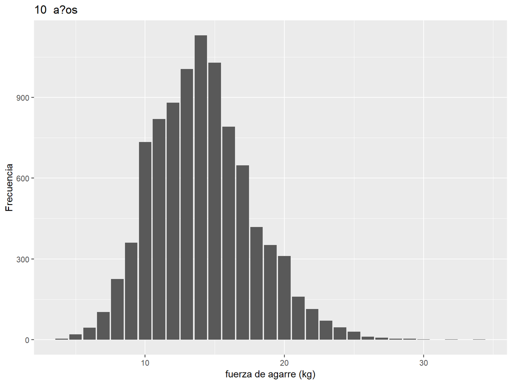

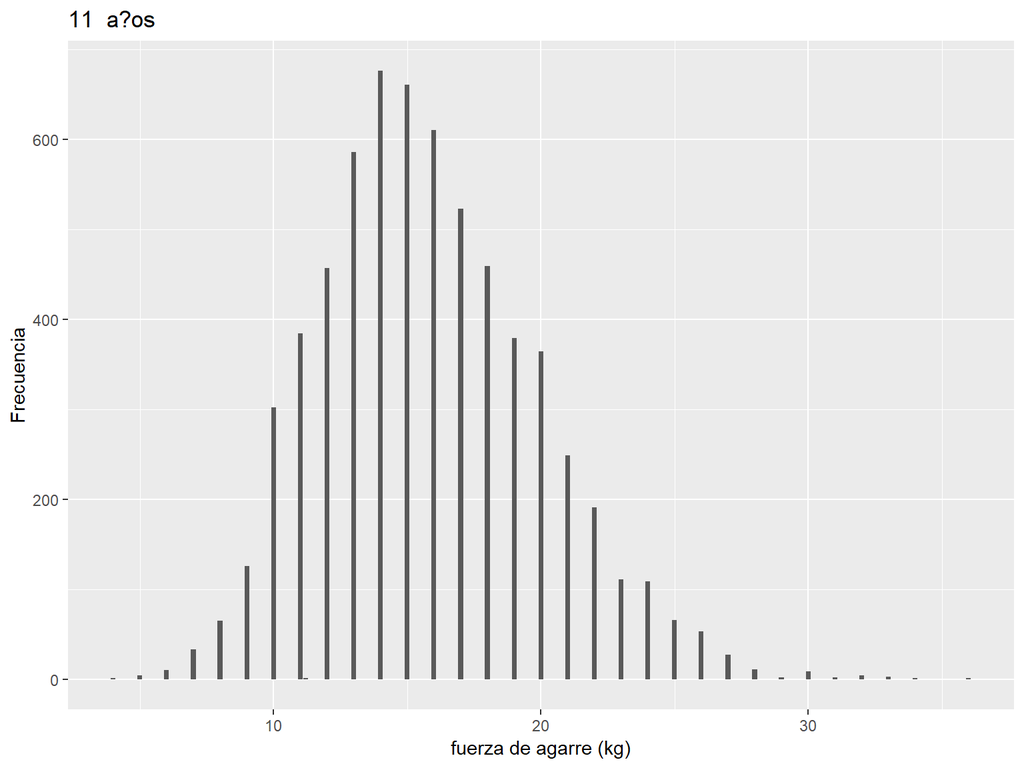

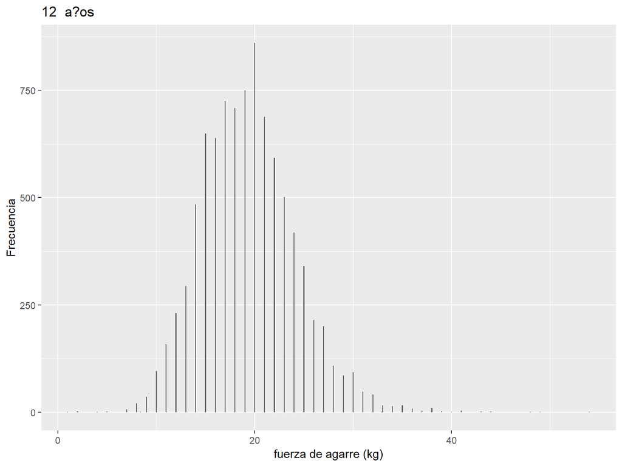

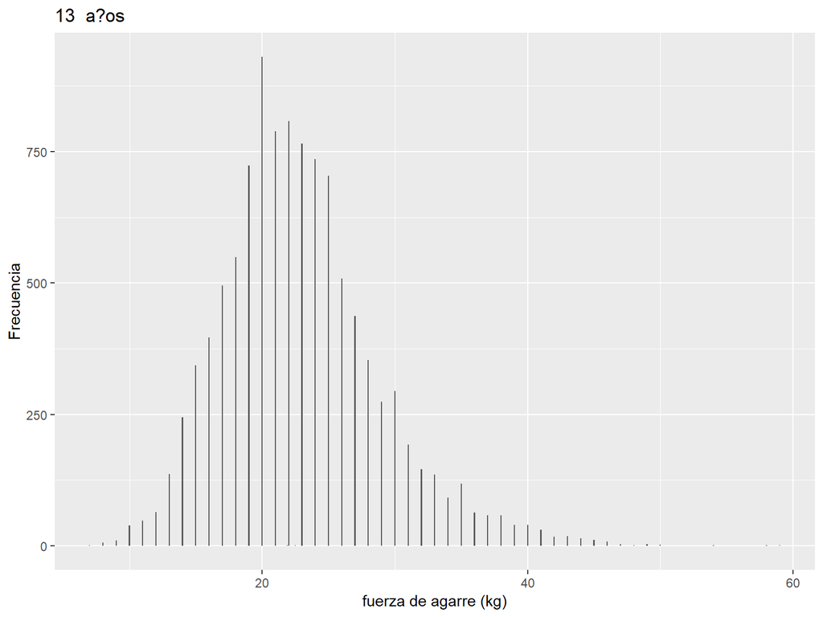

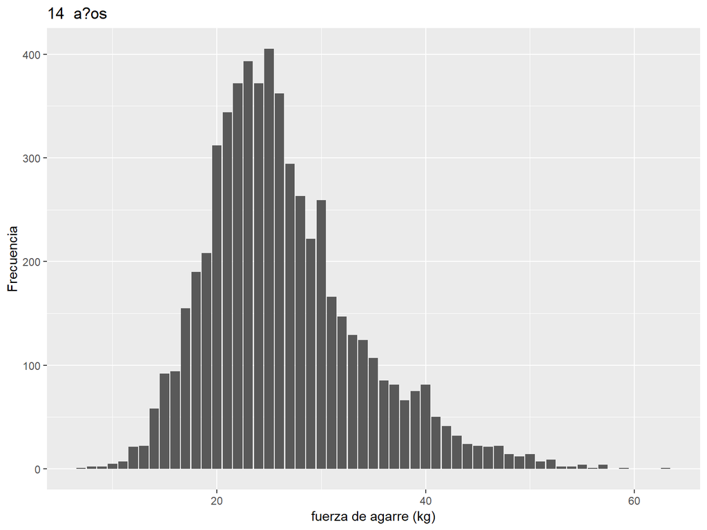

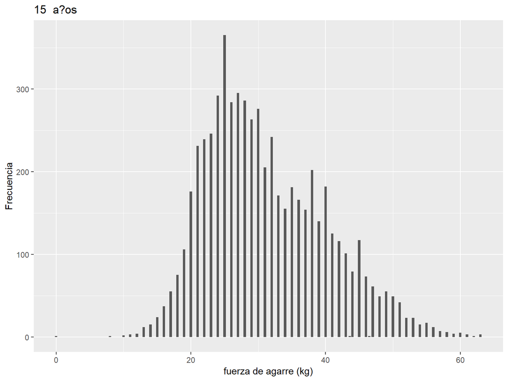

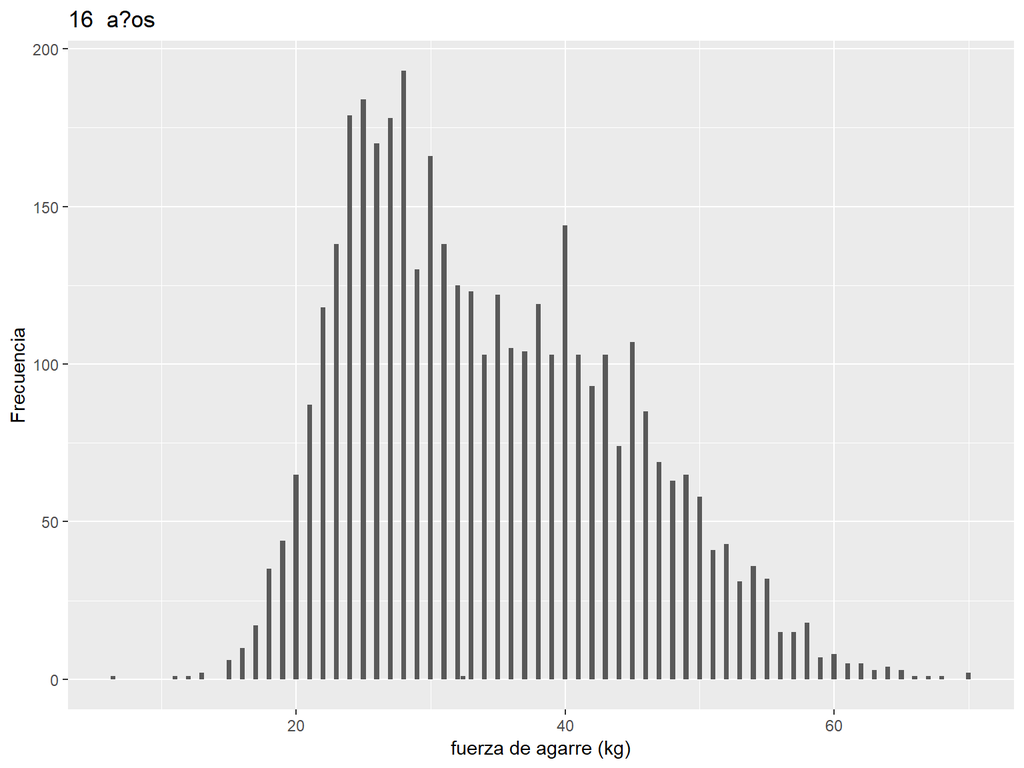

[5 more figures not shown]

```r
for(i in 5:21){
  temp <- completeData %>%
    filter(age == i)

  print(ggplot(temp, aes(x = `Hand grip`)) +
          geom_bar() +
           labs(y = "Frecuencia",
                x = "fuerza de agarre (kg)",
                title = paste(i, " a?os")
                )
  )
}
```